# Chapter 2- Exercises

```r
library(fpp3)
```

#### 1. Use the help function to explore what the series gafa_stock, PBS, vic_elec and pelt represent.

```r
?gafa_stock #stock prices for big tech from 2014-2018 DAILY (excludes weekends and holidays)
?PBS #medicare scripts MONTHLY
?vic_elec #electricy demand HALF-HOURLY
?pelt #ANNUAL pelt (ie. fur) trades
```

Use autoplot() to plot some of the series in these data sets.

```r
autoplot(gafa_stock)
autoplot(PBS) #looks weird... message that plot variable not secified
autoplot(vic_elec)
autoplot(pelt)
```

What is the time interval of each series?

```r
str(gafa_stock) #daily
str(PBS) #monthly
str(vic_elec) #electricy demand HALF-HOURLY
str(pelt) #ANNUAL pelt (ie. fur) trades
```

Use filter() to find what days corresponded to the peak closing price for each of the four stocks in gafa_stock.

```r
#didn't follow instructions specifically
gafa_stock %>% as.data.frame(gafa_stock) %>%
              select(Symbol, Close) %>%
              group_by(Symbol) %>%
              summarise(max = max(Close))
```

[output not shown]

#### 2. Download the file tute1.csv from the book website… convert the data to time series… Construct time series plots of each of the three series… check what happens when you don’t include facet_grid().

```r
tute1 <- read.csv(url("http://otexts.com/fpp3/extrafiles/tute1.csv"))
str(tute1)
```

```
'data.frame':   100 obs. of  4 variables:
 $ Quarter : Factor w/ 100 levels "1981-03-01","1981-06-01",..: 1 2 3 4 5 6 7 8 9 10 ...
 $ Sales   : num  1020 889 795 1004 1058 ...
 $ AdBudget: num  659 589 512 614 647 ...
 $ GDP     : num  252 291 291 292 279 ...
```

```r
library(lubridate)
tute1$Quarter <- ymd(tute1$Quarter)
str(tute1)
```

```
'data.frame':   100 obs. of  4 variables:
 $ Quarter : Date, format: "1981-03-01" "1981-06-01" ...
 $ Sales   : num  1020 889 795 1004 1058 ...
 $ AdBudget: num  659 589 512 614 647 ...
 $ GDP     : num  252 291 291 292 279 ...
```

```r
tute1$Quarter <- yearquarter(tute1$Quarter) #important for tsibbles, see https://otexts.com/fpp3/tsibble-objects.html
str(tute1)
```

```
'data.frame':   100 obs. of  4 variables:
 $ Quarter : yearquarter, format: "1981 Q1" "1981 Q2" ...
 $ Sales   : num  1020 889 795 1004 1058 ...
 $ AdBudget: num  659 589 512 614 647 ...
 $ GDP     : num  252 291 291 292 279 ...
```

```r
str(tute1)
```

```
Classes ‘tbl_ts’, ‘tbl_df’, ‘tbl’ and 'data.frame': 100 obs. of  4 variables:
 $ Quarter : yearquarter, format: "1981 Q1" "1981 Q2" ...
 $ Sales   : num  1020 889 795 1004 1058 ...
 $ AdBudget: num  659 589 512 614 647 ...
 $ GDP     : num  252 291 291 292 279 ...
 - attr(*, "key")=Classes ‘tbl_df’, ‘tbl’ and 'data.frame': 1 obs. of  1 variable:
  ..$ .rows:List of 1
  .. ..$ : int  1 2 3 4 5 6 7 8 9 10 ...
 - attr(*, "index")= chr "Quarter"
  ..- attr(*, "ordered")= logi TRUE
 - attr(*, "index2")= chr "Quarter"
 - attr(*, "interval")=List of 12
  ..$ year       : num 0
  ..$ quarter    : num 1
  ..$ month      : num 0
  ..$ week       : num 0
  ..$ day        : num 0
  ..$ hour       : num 0
  ..$ minute     : num 0
  ..$ second     : num 0
  ..$ millisecond: num 0
  ..$ microsecond: num 0
  ..$ nanosecond : num 0
  ..$ unit       : num 0
  ..- attr(*, "class")= chr "interval"
```

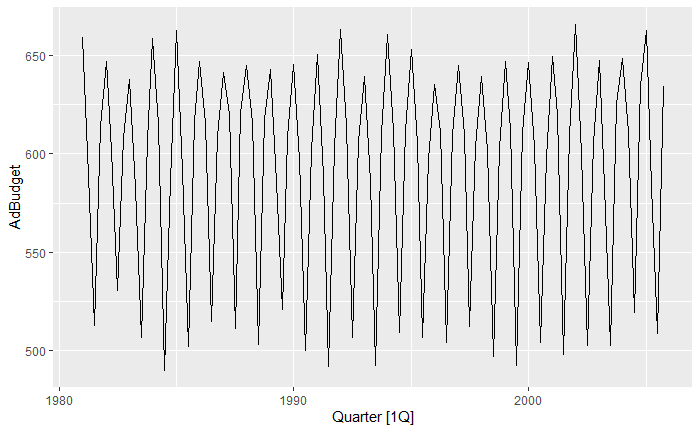

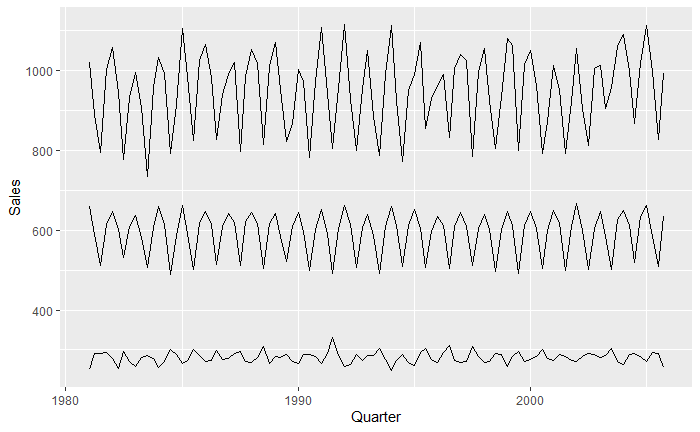

The y-axis above is incorrect, Really, we want to add a legend for each of these plots. In order to do this, we need a factor variable that defines each *y*.

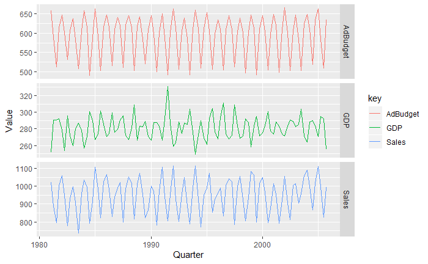

#### 3. Create time plots of the following time series: fma::bicoal, fma::chicken, fma::dole, USAccDeaths, fma::writing, fma::fancy. Use ? (or help()) to find out about the data in each series. You will need to convert each series to a tsibble using as_tsibble().

We’ll handle each dataset independently from start to finish.

```r
library(fma)
?bicoal #Annual
autoplot(bicoal) #no tsibble necessary
```

```r
?chicken
str(chicken)
autoplot(chicken)
```

[figure not shown]

```r
?USAccDeaths
autoplot(USAccDeaths)
```

[output not shown]

Remember that autoplot is a function from ggplot. It seems to work here without conversion to tsibble, so why bother?

[figure not shown]

#### 4. Use the gg_season() and gg_subseries() functions to explore the seasonal patterns in the following time series: fma::writing, fma::fancy, PBS for ATC2 “A10” and “H02”. What can you say about the seasonal patterns? Can you identify any unusual years?

We’ll go through each from start to finish.

```
Plot variable not specified, automatically selected `y = value`
```

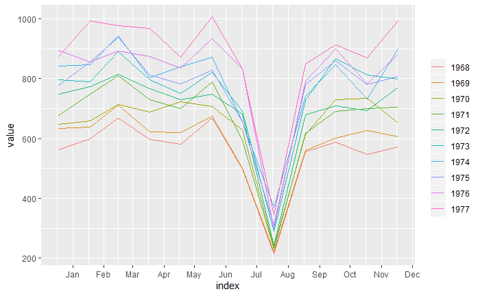

```r
gg_season(writing) #woah for whatever reason August is missing, let's try this again
```

August. Increasing trend. Some cyclicality.

```
Plot variable not specified, automatically selected `y = value`
```

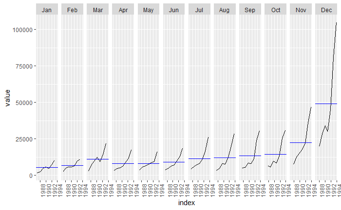

```r
gg_subseries(fancy)
```